# Cálculos con variables discretas

## Binomial 4 monedas: simular datos

- Lanzar las 4 monedas 500 veces, calcular las frecuencias relativas y realizar un gráfico donde se comparen con las probabilidades teóricas .

**Código**

```r
datos=rbinom(500,4,1/2)
frel=table(datos)/length(datos)
x1=0:4;y1=dbinom(x1,4,0.5)
plot(x1,frel,type='h',lwd=4)
lines(x1,y1,lty=2,col='red')
```

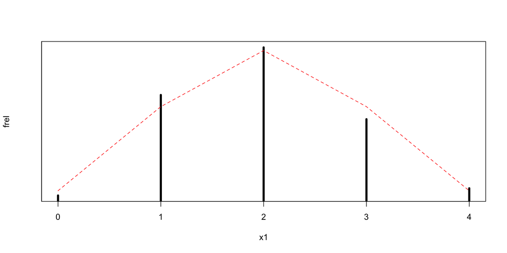

## Graficar

**Código**

```r
plot(x1,frel,type='h',lwd=4)
lines(x1,y1,lty=2,col='red')
```

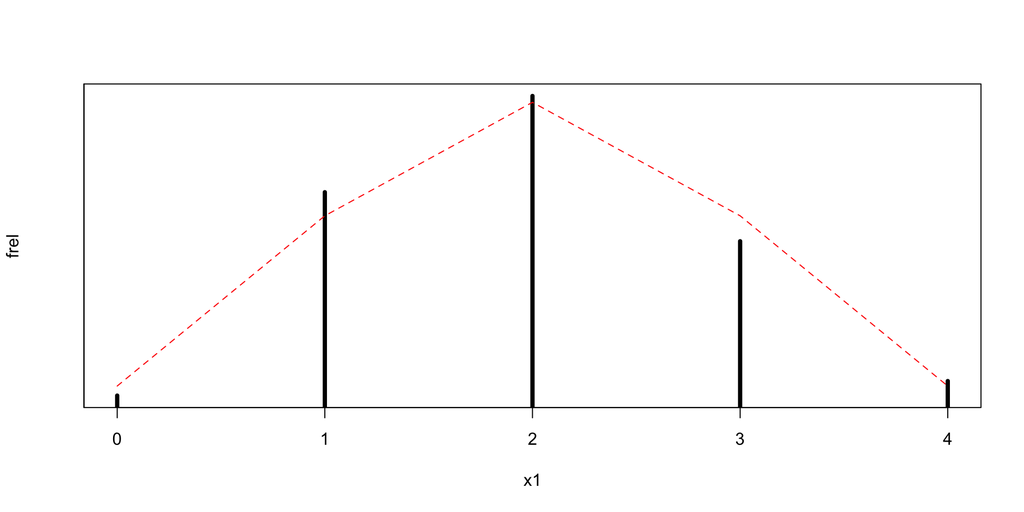

## Binomial 4 monedas: simular datos

**Código**

```r
datos=rbinom(1500,4,0.7)
frel=table(datos)/length(datos)
x1=0:4
y1=dbinom(x1,4,0.5)
plot(x1,frel,type='h',lwd=4)
lines(x1,y1,lty=2,col='red')
```

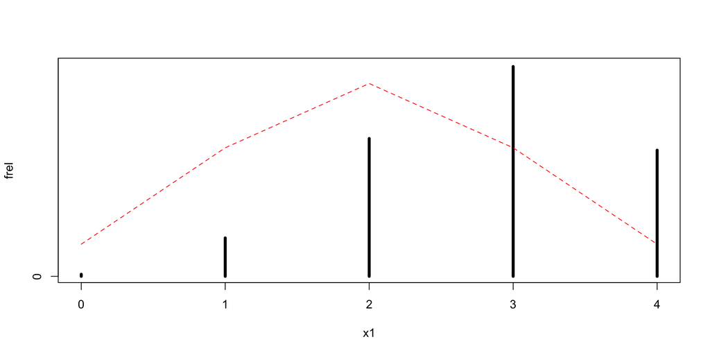

## Binomial 4 monedas: simular datos

**Código**

```r
hist(datos,freq = FALSE)
```

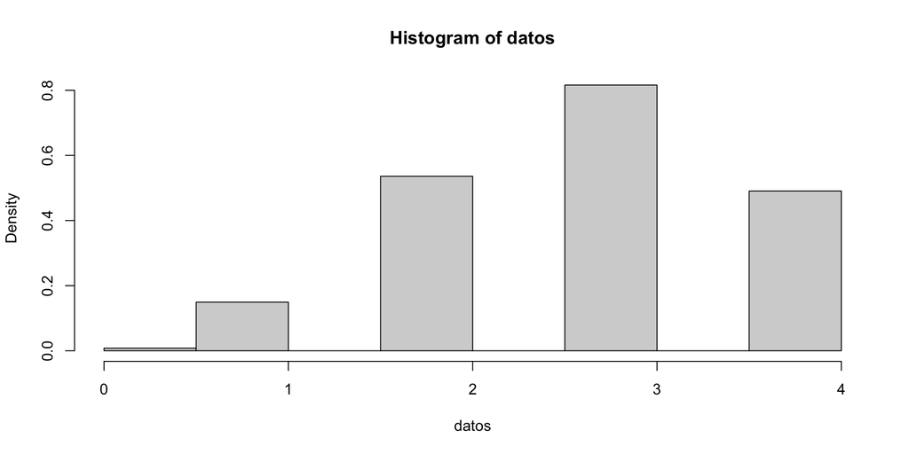

## Binomial ejemplo

Si $X$ es una variable aleatoria con distribución binomial de parámetros $n=18$ y $p=0.1$,

- Calcular $P(X=2)$

**Código**

```r
dbinom(2,18,0.1)
```

```
[1] 0.2835121
```

- Calcular $P(X \geq 3)=1-P(X\leq 2)$

**Código**

```r
1-pbinom(2,18,0.1)
```

```
[1] 0.266204
```

## Modelo binomial, gráfica ejercicio

Graficar las funciones de probabilidad de varias variables aleatorias con distribución binomial en un mismo plano, por ejemplo, a continuación se hace la gráfica de la función de probabilidad binomial con:

- $n=10$ y $p=0.1$
- $n=10$ y $p=0.5$
- $n=10$ $p=0.9$

## Modelo binomial, gráfica

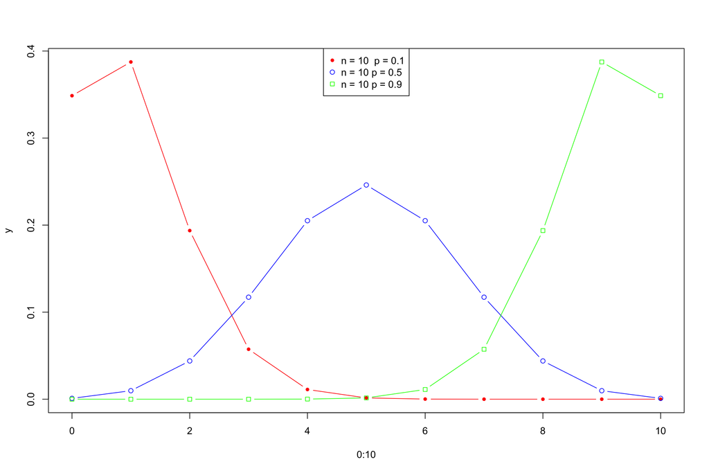

## Modelo binomial, gráfica

**Código**

```r
# n=10 p=0.1
y<-dbinom(0:10,10,0.1)
plot(0:10,y,type="b",col="red",pch=20)
# n=10 p=0.5
y<-dbinom(0:10,10,0.5)
points(0:10,y,type="b",col="blue",pch=21)
# n=10 p=0.9
y<-dbinom(0:10,10,0.9)
points(0:10,y,type="b",col="green",pch=22)

legend("top",c("n = 10  p = 0.1" ,"n = 10 p = 0.5","n = 10 p = 0.9") ,
       pch=c(20,21,22),col=c("red","blue","green"))
```

**Código**

```r
##
```

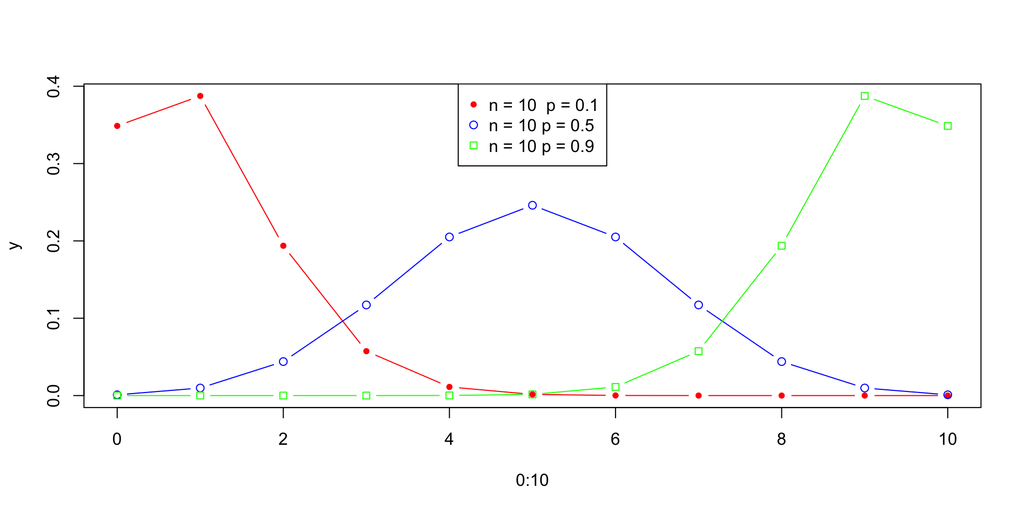

# Distribución geométrica

## Distribución geométrica

Suponga un experimento donde se tiene:

- Una serie de ensayos de Bernoulli,
- Independientes,
- probabilidad de éxito constante $p$
- Registramos el número de ensayos hasta obtener el primer éxito.

## Distribución geométrica

Sea $X$ es el número de ensayos realizados hasta la obtención del primer éxito entonces $X$ tiene una distribución geométrica con parámetro $p$ y

$$f_X(x)=P(X=x)=(1-p)^{x-1}p \hbox{ para } x=1,2,3 \cdots$$

## Distribución geométrica, ejemplo

Si $X$ es geométrica con $p=0.1$ calcular $P(X=5)$.

**OBSERVACION:** Para el calculo con el modelo geométrico con R hay que tener en cuenta que para R la variable aleatoria cuenta el número de fracasos antes del primer éxito, llamémoslo $Y$, entonces se tiene que $X=Y+1$ y por tanto $Y=X-1$ es el valor que hay que entregar a la función. Así que $P(X=5)$ se calcula mediante

**Código**

```r
dgeom(4,0.1)
```

```
[1] 0.06561
```

## Distribución geométrica, ejemplo

**Código**

```r
pgeom(124,0.01)
```

```
[1] 0.7152922
```

**Código**

```r
# equivalente a
sum(dgeom(0:124,0.01))
```

```
[1] 0.7152922
```

## Distribución geométrica, ejemplo

- Si $X$ es geométrica con $p=0.01$ obtener el menor valor de $x$ tal que $P(X\leq x)\geq 0.95$

**Código**

```r
qgeom(0.95,0.01)
```

```
[1] 298
```

## Distribución geométrica, ejemplo

Si $X$ es geométrica con $p=0.01$, generar 200 datos que sigan este modelo, graficar el histograma junto con la función de probabilidad.

**Código**

```r
datos<-rgeom(200,prob = 0.01)
h<-hist(datos,plot=FALSE)
h$counts
```

```
[1] 126  40  17  15   0   1   1
```

**Código**

```r
h$breaks
```

```
[1]   0 100 200 300 400 500 600 700
```

**Código**

```r
names(h)
```

```
[1] "breaks"   "counts"   "density"  "mids"     "xname"    "equidist"
```

## Distribución geométrica, ejemplo

**Código**

```r
minx=min(h$breaks)
maxx=max(h$breaks)
x=minx:maxx
y=dgeom(x,prob=0.01)
hist(datos,freq=FALSE)
lines(x,y,col="red",lwd=3)
```

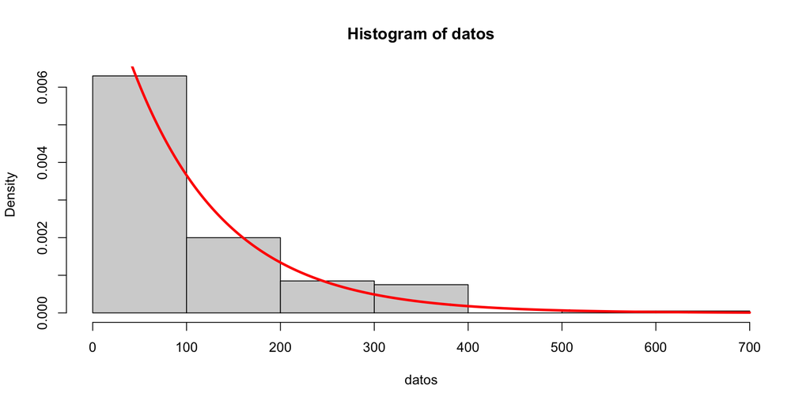

# Distribución binomial negativa

## Distribución binomial negativa

Suponga un experimento donde se tiene:

- Una serie de ensayos Bernoulli,
- Independientes,
- probabilidad de éxito constante $p$
- Registramos el número de ensayos hasta obtener $r$ éxitos.

## Distribución binomial negativa

Sea $X$ es el número de ensayos realizados hasta la obtención del $r-$ésimo éxito, entonces $X$ tiene una distribución binomial negativa con parámetros $p$ y $r=1,2,3,\ldots$

$$f_X(x;p,r)=\binom{x-1}{r-1}(1-p)^{x-r}p^r, \hbox { para } x=r, r+1 , r+2,
\cdots$$

## Distribucion binomial negativa con R

**Importante**

Para R la variable aleatoria $X$ cuenta el número de fracasos antes de los $r$ éxitos, por tanto, para calcular la probabilidad de que una variable aleatoria binomial negativa $X$ sea igual a $x$, es equivalente a calcular la probabilidad de que $Y=X-r$ sea igual a $x-r$ es decir $P(X=x)= P(Y=x-r)$ con $Y=X-r$. Luego a hay que entregarle $x-r$ para que calcule $P(X=x)$.

## Distribución binomial negativa, Ejemplo

En un departamento de control de calidad se inspeccionan las unidades terminadas que provienen de una linea de ensamble. Se piensa que la proporción de unidades defectuosas es $0.05$.

- ¿Cuál es la probabilidad de que sea necesario inspeccionar 20 unidades hasta encontrar 2 defectuosas?
- ¿Cuál es la probabilidad de tener que realizar 30 ensayos o menos para encontrar encontrar 3 defectuosas? Se pide
  $$P(X\leq 30)$$
  con $X$ una binomial negativa de parámetros $r=3$ y $p=0.05$

## Distribución binomial negativa, Solución

**Código**

```r
dnbinom(x = 18,size = 2,prob = 0.05)
```

```
[1] 0.01886768
```

**Código**

```r
pnbinom(27,3,0.05)
```

```
[1] 0.1878212
```

## Distribución binomial negativa, ejemplo

Si $X$ es una variable aleatoria con distribución binomial negativa de parámetros $r=3$ y $p=0.05$, obtener el menor valor de $x$ tal que $P(X\leq x)\geq 0.5$

**Código**

```r
qnbinom(p = 0.5,size = 3,prob = 0.05)
```

```
[1] 51
```

## Distribución binomial negativa

### Simulación

**Código**

```r
datos=rnbinom(200,size = 5,prob = 0.1)
h<-hist(datos,prob=TRUE)
minx=min(h$breaks)
maxx=max(h$breaks)
x=minx:maxx
y=dnbinom(x,size = 5,prob=0.1)
lines(x,y,col="red",lwd=3)
```

## Distribución binomial negativa

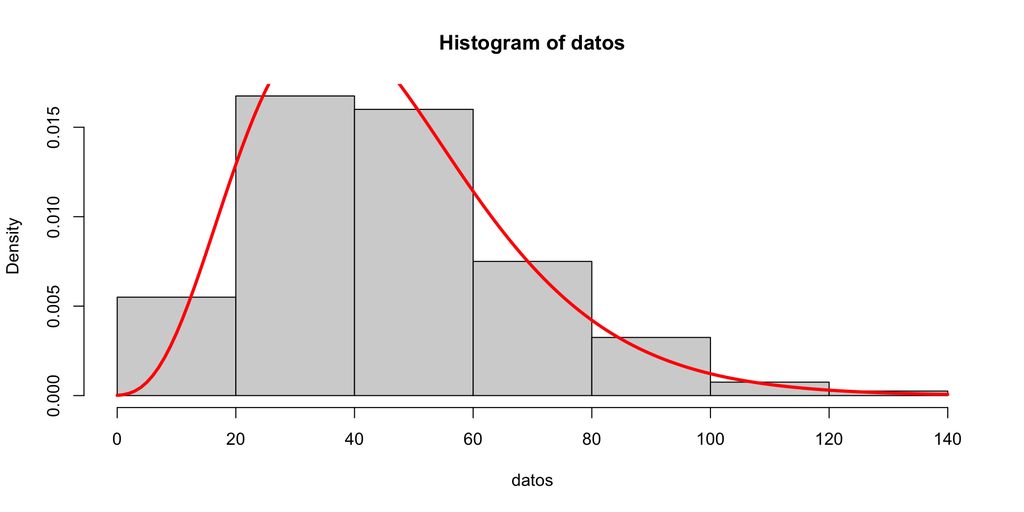

# Distribución hipergeométrica

## Distribución hipergeométrica

Un conjunto de $N$ objetos contiene

- $m$ $(m\leq N)$ elementos con el atributo $A$, los cuales se consideran éxitos.
- $n=N-m$ sin el atributo ($A^c$)
- Se toma una muestra de tamaño $k$, $(k\leq N)$ al azar (sin remplazo).
- Sea $X$ el número de éxitos (elementos con el atributo $A$) en la muestra.

## Distribución hipergeométrica

Entonces $X$ tiene **distribución hipergeométrica** con función de probabilidad.
$$f_X(x)=\frac{\binom{m}{x}\binom{n}{k-x}}{\binom{N}{k}} \hbox{ con } x=0,1,\ldots,\min\{m,k\}$$

## Distribución hipergeométrica, esquema

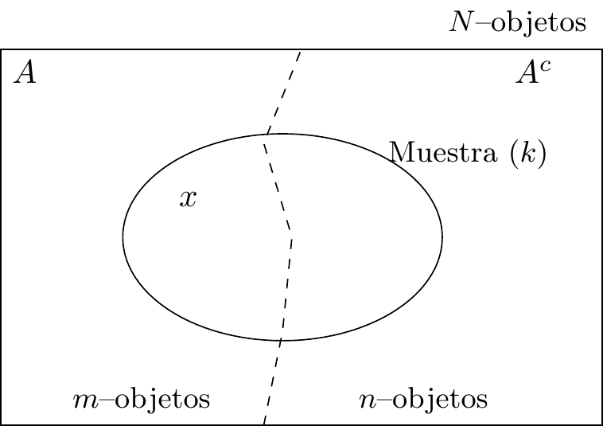

Esquematización de una distribución hipergeométrica $m+n=N$

## Distribución hipergeométrica, ejemplo

Un lote de piezas contiene 100 de un proveedor local de tuberías, y 300 de un proveedor de otro estado. Si se eligen 10 piezas al azar y sin remplazo

- ¿Cuál es la probabilidad que 5 provengan del proveedor local?
- ¿Cuál es la probabilidad de que 3 o menos provengan del proveedor local?
- Obtenga el menor valor de $x$ tal que $P(X\leq x)\geq 0.95$

## Distribución hipergeométrica, solución

En este caso se toma como éxito que el origen de la pieza sea del proveedor local. Sea $X$ el número de piezas del proveedor local en la muestra, entonces $X$ tiene distribución hipergeométrica con parámetros $m=100$, $n=300$, $k=10$

**Código**

```r
dhyper(5, m = 100, n=300, k=10)
```

```
[1] 0.05714935
```

**Código**

```r
phyper(3, m = 100, n=300, k=10)
```

```
[1] 0.7781091
```

**Código**

```r
qhyper(0.95, m = 100, n=300, k=10)
```

```
[1] 5
```

## Distribuciones Binomial e hipergeométrica

Probabilidades calculadas con la hipergeometrica

### Solución

**Código**

```r
# parámetros de la hipergeometrica
m=1000
n=3000
k=70
# valores de x
x=0:min(c(m,k))
yh=dhyper(x,m = m,n = n,k = k)
```

## Distribuciones Binomial e hipergeométrica

Probabilidades calculadas con la binomial

### Solución

**Código**

```r
p=m/(m+n) # probabilidad de éxito
yb=dbinom(x,size=k,prob = p)
```

## Distribuciones Binomial e hipergeométrica

**Código**

```r
plot(x,yh,type='b',col='black')
lines(x,yb,type='b',col='red')
legend('top',legend= c('Hipergeo','Binomial'),col=c('black','red'),lty=2,pch=1)
```

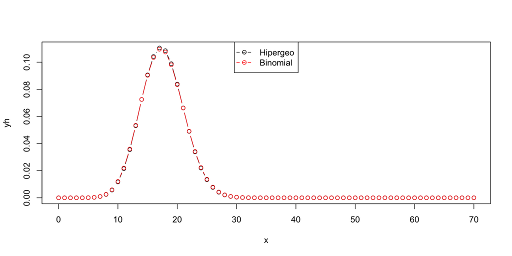

## Para consultar

- Distribución de Poisson
- Aproximación de la distribución de Poisson a la Binomial.